# Ionosphere Classification using Decision Trees

Timothee RINGUYNEZA

2026-05-12

## Background

This analysis applies **decision tree classification** to the **UCI Ionosphere dataset**, collected by a phased-array radar system in Goose Bay, Labrador.

## Part 1 — Print the Decision Tree

### 1a. Setup: Load Packages and Data

```r
library(rpart)
library(mlbench)
library(rpart.plot)

data(Ionosphere)

cat("Dimensions:", nrow(Ionosphere), "x", ncol(Ionosphere), "\n")
```

```
## Dimensions: 351 x 35
```

```r
table(Ionosphere$Class)
```

```
##
##  bad good
##  126  225
```

The dataset contains **351 observations** and **35 variables** (34 features + 1 class label).

### 1b. Build the Decision Tree

```r
tree_full <- rpart(Class ~ ., data = Ionosphere)
print(tree_full)
```

```
## n= 351
##
## node), split, n, loss, yval, (yprob)
##       * denotes terminal node
##
##  1) root 351 126 good (0.35897436 0.64102564)
##    2) V5< 0.23154 77   4 bad (0.94805195 0.05194805) *
##    3) V5>=0.23154 274  53 good (0.19343066 0.80656934)
##      6) V27>=0.999945 52  13 bad (0.75000000 0.25000000)
##       12) V1=0 19   0 bad (1.00000000 0.00000000) *
##       13) V1=1 33  13 bad (0.60606061 0.39393939)
##         26) V3< 0.73004 8   0 bad (1.00000000 0.00000000) *
##         27) V3>=0.73004 25  12 good (0.48000000 0.52000000)
##           54) V22>=0.47714 9   1 bad (0.88888889 0.11111111) *
##           55) V22< 0.47714 16   4 good (0.25000000 0.75000000) *
##      7) V27< 0.999945 222  14 good (0.06306306 0.93693694) *
```

### 1c. Plot the Decision Tree

**Basic plot using `plot()` and `text()`:**

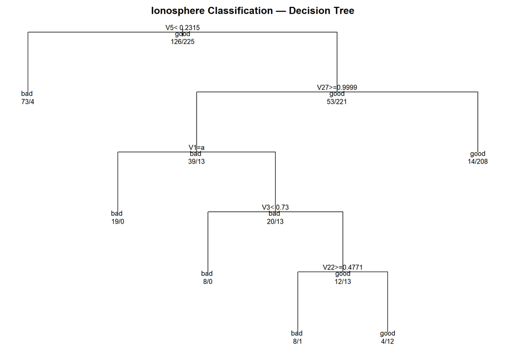

Basic Decision Tree - Ionosphere Classification

```r
par(mar = c(1, 1, 2, 1))
plot(tree_full, uniform = TRUE,
     main = "Ionosphere Classification — Decision Tree")
text(tree_full, use.n = TRUE, all = TRUE, cex = 0.8)
```

**Enhanced plot using `rpart.plot`:**

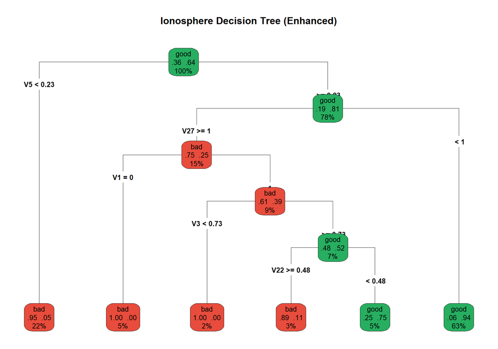

Enhanced Decision Tree with class probabilities

```r
rpart.plot(
  tree_full,
  type          = 4,
  extra         = 104,
  fallen.leaves = TRUE,
  main          = "Ionosphere Decision Tree (Enhanced)",
  cex           = 0.85,
  box.palette   = list(bad = "#E74C3C", good = "#27AE60")
)
```

**Interpretation:** Each node shows the predicted class, class probabilities, and the percentage of observations reaching that node. The tree splits primarily on radar pulse features (V3, V5, etc.).

## Part 2 — Estimate Accuracy

### 2a. Train / Test Split

```r
set.seed(42)
n     <- nrow(Ionosphere)
train <- sample(1:n, size = floor(0.7 * n), replace = FALSE)
test  <- setdiff(1:n, train)

cat("Training size:", length(train), "\n")
```

```
## Training size: 245
```

```r
cat("Testing size :", length(test),  "\n")
```

```
## Testing size : 106
```

### 2b. Build Tree on Training Data

```r
tree_train <- rpart(Class ~ ., data = Ionosphere, subset = train)
print(tree_train)
```

```
## n= 245
##
## node), split, n, loss, yval, (yprob)
##       * denotes terminal node
##
##  1) root 245 79 good (0.32244898 0.67755102)
##    2) V5< 0.145975 48  2 bad (0.95833333 0.04166667) *
##    3) V5>=0.145975 197 33 good (0.16751269 0.83248731)
##      6) V27>=0.99921 33 10 bad (0.69696970 0.30303030)
##       12) V22>=-0.009455 19  2 bad (0.89473684 0.10526316) *
##       13) V22< -0.009455 14  6 good (0.42857143 0.57142857) *
##      7) V27< 0.99921 164 10 good (0.06097561 0.93902439) *
```

### 2c. Predict on Test Data

```r
predictions <- predict(tree_train,
                       newdata = Ionosphere[test, ],
                       type    = "class")
head(predictions)
```

```
##    8    9   17   19   22   23
##  bad good good good  bad good
## Levels: bad good
```

### 2d. Confusion Table and Accuracy

```r
true_labels <- Ionosphere$Class[test]
conf_table  <- table(Predicted = predictions, Actual = true_labels)
print(conf_table)
```

```
##          Actual
## Predicted bad good
##      bad   36    3
##      good  11   56
```

```r
TP       <- conf_table["good", "good"]
TN       <- conf_table["bad",  "bad"]
accuracy <- (TP + TN) / length(test)

cat(sprintf("\nAccuracy = (%d + %d) / %d = %.4f (%.2f%%)\n",
            TP, TN, length(test), accuracy, accuracy * 100))
```

```
##
## Accuracy = (56 + 36) / 106 = 0.8679 (86.79%)
```

**The model achieves approximately 86.8% accuracy** on the held-out test set.

## Bonus — 10-Fold Cross-Validation

```r
set.seed(42)
k      <- 10
folds  <- cut(sample(1:n), breaks = k, labels = FALSE)
cv_acc <- numeric(k)

for (i in 1:k) {
  cv_test  <- which(folds == i)
  cv_train <- which(folds != i)
  cv_tree  <- rpart(Class ~ ., data = Ionosphere, subset = cv_train)
  cv_pred  <- predict(cv_tree, newdata = Ionosphere[cv_test, ], type = "class")
  cv_acc[i] <- mean(cv_pred == Ionosphere$Class[cv_test])
}

cat(sprintf("Mean CV Accuracy: %.4f (%.2f%%)\n", mean(cv_acc), mean(cv_acc) * 100))
```

```
## Mean CV Accuracy: 0.8691 (86.91%)
```

```r
cat(sprintf("Std Dev: %.4f\n", sd(cv_acc)))
```

```
## Std Dev: 0.0628
```

## Summary

[output not shown]

The decision tree classifier performs well on this dataset, correctly identifying ionospheric structure in radar returns with high accuracy. The tree is interpretable and reveals which pulse features are most discriminative.